# MACHINE LEARNING - HYPERPARAMETER TUNING

## Model building - Logistic Regression

- Making a logistic regression model - Improving model performance by up and downsampling the data - Regularizing above models, if required

```python
lr = LogisticRegression(random_state=1)
lr.fit(X_train,y_train)
```

```
LogisticRegression(random_state=1)
```

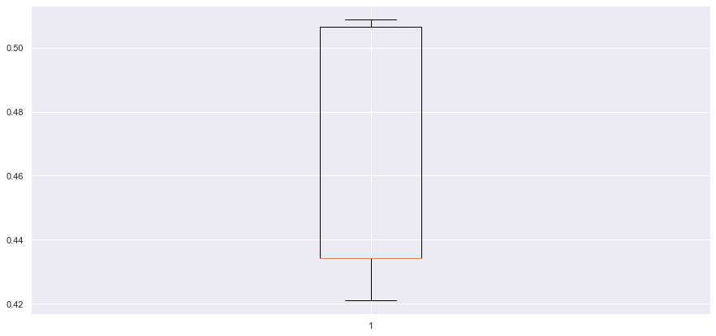

```python
scoring='recall'
kfold=StratifiedKFold(n_splits=5,shuffle=True,random_state=1)     #Setting number of splits equal to 5
cv_result_bfr=cross_val_score(estimator=lr, X=X_train, y=y_train, scoring=scoring, cv=kfold)
#Plotting boxplots for CV scores of model defined above
plt.boxplot(cv_result_bfr)
plt.show()
```

```
Accuracy on training set :  0.8920711060948081
Accuracy on test set :  0.8953603158933859
Recall on training set :  0.5083406496927129
Recall on test set :  0.5225409836065574
Precision on training set :  0.7385204081632653
Precision on test set :  0.75
```

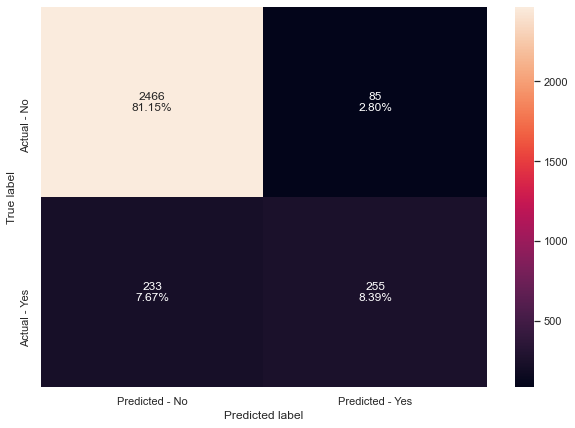

```python
#Calculating different metrics
scores_LR = get_metrics_score(lr)

# creating confusion matrix
make_confusion_matrix(lr,y_test)
```

- Logistic Regression gives a certain performance in accuracy on training and test set.
- Recall is very low with 0.52, we can try oversampling/undersampling (increase/decrease training data) to see if the model performance can be improved.

### Oversampling train data using SMOTE

```python
from imblearn.over_sampling import SMOTE
```

```python
print("Before UpSampling, counts of label 'Yes': {}".format(sum(y_train==1)))
print("Before UpSampling, counts of label 'No': {} \n".format(sum(y_train==0)))

sm = SMOTE(sampling_strategy = 1 ,k_neighbors = 5, random_state=1)   #Synthetic Minority Over Sampling Technique
X_train_over, y_train_over = sm.fit_resample(X_train, y_train)


print("After UpSampling, counts of label 'Yes': {}".format(sum(y_train_over==1)))
print("After UpSampling, counts of label 'No': {} \n".format(sum(y_train_over==0)))


print('After UpSampling, the shape of train_X: {}'.format(X_train_over.shape))
print('After UpSampling, the shape of train_y: {} \n'.format(y_train_over.shape))
```

```
Before UpSampling, counts of label 'Yes': 1139
Before UpSampling, counts of label 'No': 5949

After UpSampling, counts of label 'Yes': 5949
After UpSampling, counts of label 'No': 5949

After UpSampling, the shape of train_X: (11898, 7)
After UpSampling, the shape of train_y: (11898,)
```

### Logistic Regression on oversampled data

```python
log_reg_over = LogisticRegression(random_state = 1)

# Training the basic logistic regression model with training set
log_reg_over.fit(X_train_over,y_train_over)
```

```
LogisticRegression(random_state=1)
```

**Let's evaluate the model performance by using KFold and cross_val_score**

- 'K-Folds cross-validator' provides dataset indices to split data into train/validation sets. Split dataset into k consecutive stratified folds (without shuffling by default). Each fold is then used once as validation while the k - 1 remaining folds form the training set.

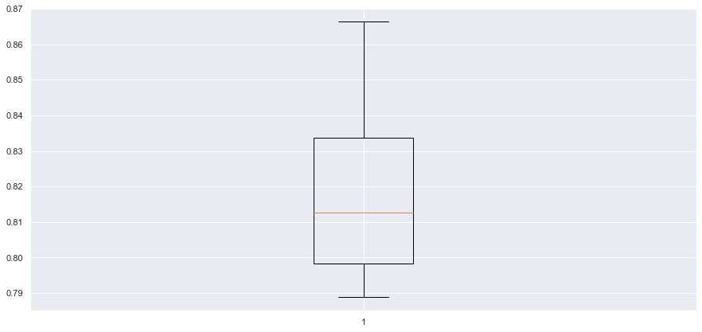

```python
scoring='recall'
kfold=StratifiedKFold(n_splits=5,shuffle=True,random_state=1)     #Setting number of splits equal to 5
cv_result_over=cross_val_score(estimator=log_reg_over, X=X_train_over, y=y_train_over, scoring=scoring, cv=kfold)
#Plotting boxplots for CV scores of model defined above
plt.boxplot(cv_result_over)
plt.show()
```

- Performance of model on training set varies between 0.79 to 0.86, which is an improvement from the previous model
- Let's check the performance on the test set.

```
Accuracy on training set :  0.8201185101580135
Accuracy on test set :  0.8140835801250411
Recall on training set :  0.835820895522388
Recall on test set :  0.8360655737704918
Precision on training set :  0.4666666666666667
Precision on test set :  0.4568868980963046
```

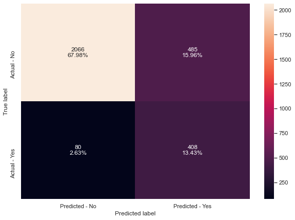

```python
#Calculating different metrics
get_metrics_score(log_reg_over)

# creating confusion matrix
make_confusion_matrix(log_reg_over,y_test)
```

- Performance on the training set improved and also the model is able to replicate the same for the test set, with recall=0.83.
- Then the model is not overfitting and we dont need to make a regularization.
- Let's observe that we pay a price to improve the recall, in this case the precision decrease considerably, but for this problem the important variable is the recall, then it is welcome such an improvement on it.
- We check now undersampling the train to handle the imbalance between classes and check the model performance.

```python
from imblearn.under_sampling import RandomUnderSampler
rus = RandomUnderSampler(random_state = 1)
X_train_un, y_train_un = rus.fit_resample(X_train, y_train)
```

```python
print("Before Under Sampling, counts of label 'Yes': {}".format(sum(y_train==1)))
print("Before Under Sampling, counts of label 'No': {} \n".format(sum(y_train==0)))

print("After Under Sampling, counts of label 'Yes': {}".format(sum(y_train_un==1)))
print("After Under Sampling, counts of label 'No': {} \n".format(sum(y_train_un==0)))

print('After Under Sampling, the shape of train_X: {}'.format(X_train_un.shape))
print('After Under Sampling, the shape of train_y: {} \n'.format(y_train_un.shape))
```

```
Before Under Sampling, counts of label 'Yes': 1139
Before Under Sampling, counts of label 'No': 5949

After Under Sampling, counts of label 'Yes': 1139
After Under Sampling, counts of label 'No': 1139

After Under Sampling, the shape of train_X: (2278, 7)
After Under Sampling, the shape of train_y: (2278,)
```

### Logistic Regression on undersampled data

```python
log_reg_under = LogisticRegression(random_state = 1)
log_reg_under.fit(X_train_un,y_train_un )
```

```
LogisticRegression(random_state=1)
```

**Let's evaluate the model performance by using KFold and cross_val_score**

- 'K-Folds cross-validator' provides dataset indices to split data into train/validation sets. Split dataset into k consecutive stratified folds (without shuffling by default). Each fold is then used once as validation while the k - 1 remaining folds form the training set.

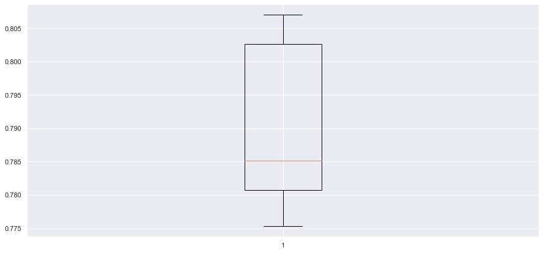

```python
scoring='recall'
kfold=StratifiedKFold(n_splits=5,shuffle=True,random_state=1)     #Setting number of splits equal to 5
cv_result_under=cross_val_score(estimator=log_reg_under, X=X_train_un, y=y_train_un, scoring=scoring, cv=kfold)
#Plotting boxplots for CV scores of model defined above
plt.boxplot(cv_result_under)
plt.show()
```

```
Accuracy on training set :  0.8232223476297968
Accuracy on test set :  0.8068443566962816
Recall on training set :  0.7928007023705005
Recall on test set :  0.7971311475409836
Precision on training set :  0.4703125
Precision on test set :  0.443557582668187
```

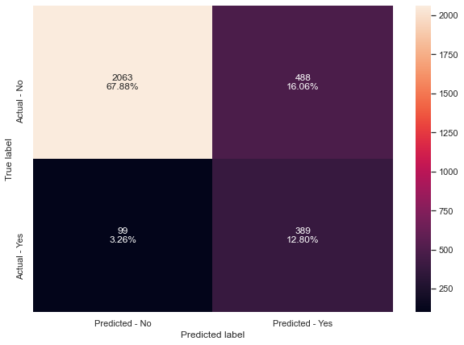

```python
#Calculating different metrics
get_metrics_score(log_reg_under)

# creating confusion matrix
make_confusion_matrix(log_reg_under,y_test)
```

- Performance on the training set improved and also the model is able to replicate the same for the test set, with recall=0.79, a bit lower than in the case of oversampling.
- Then the model is not overfitting and we dont need to make a regularization.
- Also here let's observe that we pay a price to improve the recall, in this case the precision decrease considerably, but for this problem the important variable is the recall, then it is welcome such an improvement on it.

```python
# defining list of model
models = [lr]

# defining empty lists to add train and test results
acc_train = []
acc_test = []
recall_train = []
recall_test = []
precision_train = []
precision_test = []

# looping through all the models to get the metrics score - Accuracy, Recall and Precision
for model in models:

    j = get_metrics_score(model,False)
    acc_train.append(j[0])
    acc_test.append(j[1])
    recall_train.append(j[2])
    recall_test.append(j[3])
    precision_train.append(j[4])
    precision_test.append(j[5])
```

```python
# defining list of models
models = [log_reg_over]

# looping through all the models to get the metrics score - Accuracy, Recall and Precision
for model in models:

    j = get_metrics_score(model,False)
    acc_train.append(j[0])
    acc_test.append(j[1])
    recall_train.append(j[2])
    recall_test.append(j[3])
    precision_train.append(j[4])
    precision_test.append(j[5])
```

```python
# defining list of model
models = [log_reg_under]

# looping through all the models to get the metrics score - Accuracy, Recall and Precision
for model in models:

    j = get_metrics_score(model,False)
    acc_train.append(j[0])
    acc_test.append(j[1])
    recall_train.append(j[2])
    recall_test.append(j[3])
    precision_train.append(j[4])
    precision_test.append(j[5])
```

```python
comparison_frame = pd.DataFrame({'Model':['Logistic Regression','LR on Oversampled data','LR on Undersampled data'],
                                          'Train_Accuracy': acc_train,'Test_Accuracy': acc_test,
                                          'Train_Recall':recall_train,'Test_Recall':recall_test,
                                          'Train_Precision':precision_train,'Test_Precision':precision_test})

#Sorting models in decreasing order of test recall
comparison_frame
```

|  | Model | Train_Accuracy | Test_Accuracy | Train_Recall | Test_Recall | Train_Precision | Test_Precision |
| --- | --- | --- | --- | --- | --- | --- | --- |
| 0 | Logistic Regression | 0.892071 | 0.895360 | 0.508341 | 0.522541 | 0.738520 | 0.750000 |
| 1 | LR on Oversampled data | 0.820119 | 0.814084 | 0.835821 | 0.836066 | 0.466667 | 0.456887 |
| 2 | LR on Undersampled data | 0.823222 | 0.806844 | 0.792801 | 0.797131 | 0.470313 | 0.443558 |

- Logistic regression model on oversampled data has given a generalized performance with the highest recall on test data.

### Finding the coefficients

```python
log_odds = log_reg_over.coef_[0]
pd.DataFrame(log_odds, X_train_un.columns, columns=['coef']).T
```

|  | Total_Trans_Ct | Total_Ct_Chng_Q4_Q1 | Total_Revolving_Bal | Contacts_Count_12_mon | Total_Trans_Amt | Months_Inactive_12_mon | Total_Relationship_Count |
| --- | --- | --- | --- | --- | --- | --- | --- |
| coef | -0.102994 | -0.58403 | -0.000793 | 0.159128 | 0.000376 | 0.932489 | -0.332406 |

### Converting coefficients to odds

```python
odds = np.exp(np.abs(log_reg_over.coef_[0]))-1
pd.set_option('display.max_rows',None)
pd.DataFrame(odds, X_train_un.columns, columns=['odds']).T
```

|  | Total_Trans_Ct | Total_Ct_Chng_Q4_Q1 | Total_Revolving_Bal | Contacts_Count_12_mon | Total_Trans_Amt | Months_Inactive_12_mon | Total_Relationship_Count |
| --- | --- | --- | --- | --- | --- | --- | --- |
| odds | 0.108485 | 0.793251 | 0.000793 | 0.172489 | 0.000376 | 1.540825 | 0.394319 |

## Model Building - Bagging and Boosting

- Building Bagging, Random Forest and Decision tree classifier models
- Building AdaBoost, Gradient Boosting and XGBoost models

### Building the models

- We are going to build these ensemble models here - Bagging Classifier, Random Forest Classifier and Decision Tree.
- First, let's build these models with default parameters and then use hyperparameter tuning to optimize the model performance.
- We will calculate all three metrics - Accuracy, Precision and Recall but the metric of interest here is recall.
- 'Recall' - It gives the ratio of True positives to Actual positives, so high Recall implies low false negatives, i.e. low chances of predicting an Attrition_Flag as non Attrition_Flag.

### Bagging Classifier

```python
#base_estimator for bagging classifier is a decision tree by default
bagging_estimator=BaggingClassifier(random_state=1)
bagging_estimator.fit(X_train,y_train)
```

```
BaggingClassifier(random_state=1)
```

```python
#Using above defined function to get accuracy, recall and precision on train and test set
bagging_estimator_score=get_metrics_score(bagging_estimator)
```

```
Accuracy on training set :  0.9957674943566591
Accuracy on test set :  0.9480092135570911
Recall on training set :  0.9798068481123793
Recall on test set :  0.8237704918032787
Precision on training set :  0.993766696349065
Precision on test set :  0.8481012658227848
```

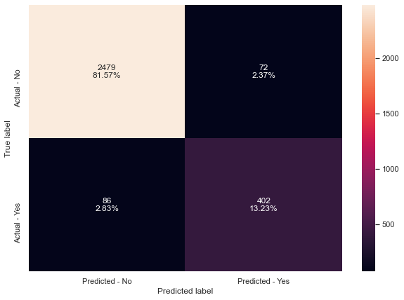

```python
make_confusion_matrix(bagging_estimator,y_test)
```

### Random Forest Classifier

```python
#Train the random forest classifier
rf_estimator=RandomForestClassifier(random_state=1)
rf_estimator.fit(X_train,y_train)
```

```
RandomForestClassifier(random_state=1)
```

```python
#Using above defined function to get accuracy, recall and precision on train and test set
rf_estimator_score=get_metrics_score(rf_estimator)
```

```
Accuracy on training set :  1.0
Accuracy on test set :  0.9562356038170451
Recall on training set :  1.0
Recall on test set :  0.8483606557377049
Precision on training set :  1.0
Precision on test set :  0.8752642706131079
```

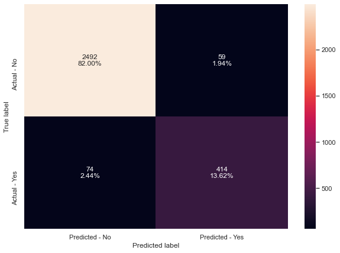

```python
make_confusion_matrix(rf_estimator,y_test)
```

### Decision Tree Model

```python
#Train the Decision Tree
dtree=DecisionTreeClassifier(random_state=1)
dtree.fit(X_train,y_train)
```

```
DecisionTreeClassifier(random_state=1)
```

```python
#Using above defined function to get accuracy, recall and precision on train and test set
dtree_estimator_score=get_metrics_score(dtree)
```

```
Accuracy on training set :  1.0
Accuracy on test set :  0.9312273774267851
Recall on training set :  1.0
Recall on test set :  0.8299180327868853
Precision on training set :  1.0
Precision on test set :  0.7627118644067796
```

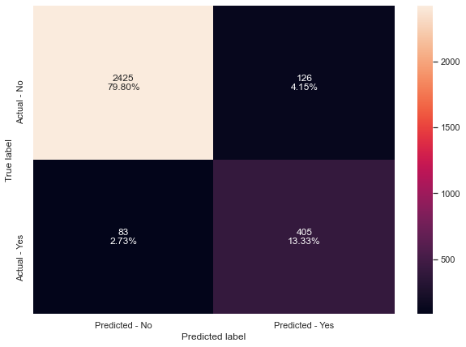

```python
make_confusion_matrix(dtree,y_test)
```

**Results with default parameters:**

- Random forest classifier and decision tree are overfitting the train data.
- The 3 models are giving similar performance in terms of accuracy but RF classifier is giving a better recall and precision.
- The best model at this step is the RF model if our principal guide is the recall parameter, as it was already signaled in the first above general checking.

### AdaBoost Classifier

```
Accuracy on training set :  0.952313769751693
Accuracy on test set :  0.9486673247778875
Recall on training set :  0.8244073748902546
Recall on test set :  0.8319672131147541
Precision on training set :  0.871866295264624
Precision on test set :  0.8458333333333333
```

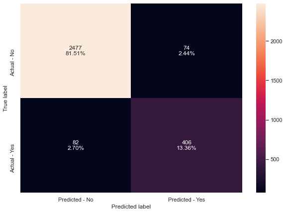

```python
abc = AdaBoostClassifier(random_state=1)
abc.fit(X_train,y_train)

#Using above defined function to get accuracy, recall and precision on train and test set
abc_score=get_metrics_score(abc)

make_confusion_matrix(abc,y_test)
```

### GradientBoost Classifier

```
Accuracy on training set :  0.9640237020316027
Accuracy on test set :  0.9529450477130635
Recall on training set :  0.8410886742756805
Recall on test set :  0.8319672131147541
Precision on training set :  0.9282945736434108
Precision on test set :  0.8693790149892934
```

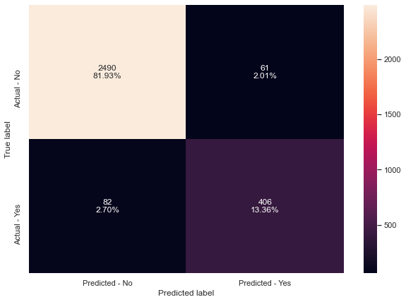

```python
gbc = GradientBoostingClassifier(random_state=1)
gbc.fit(X_train,y_train)

#Using above defined function to get accuracy, recall and precision on train and test set
gbc_score=get_metrics_score(gbc)

make_confusion_matrix(gbc,y_test)
```

### XGBoost Classifier

```
Accuracy on training set :  0.998589164785553
Accuracy on test set :  0.9555774925962488
Recall on training set :  0.9973661106233538
Recall on test set :  0.8770491803278688
Precision on training set :  0.9938757655293088
Precision on test set :  0.8508946322067594
```

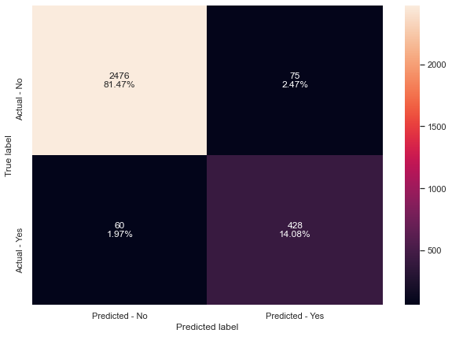

```python
xgb = XGBClassifier(random_state=1,objective='binary:logistic',eval_metric='logloss')
xgb.fit(X_train,y_train)

#Using above defined function to get accuracy, recall and precision on train and test set
xgb_score=get_metrics_score(xgb)

make_confusion_matrix(xgb,y_test)
```

**Results with default parameters:**

- It is clear that the best performance of the last 3 models is for the XGB classifier.
- We will perform the tuning of the RF and XGB classifiers in the next steps.

## Tuning of the RF and XGB Models

## Hyperparameter tuning using grid search

- Tuning of some models using grid search - Use of pipelines in hyperparameter tuning

### Random Forest Classifier

**Now, let's see if we can get a better model by tuning the random forest classifier.**

```python
# Choose the type of classifier.
rf_estimator_tuned = RandomForestClassifier(random_state=1)

# Grid of parameters to choose from
## add from article
parameters = {"n_estimators": [80,100,120],
              "min_samples_leaf": [2,3,4],
              "max_features": [0.7,0.8,0.9],
              "max_samples": [0.7,0.8,0.9],
             }

# Type of scoring used to compare parameter combinations
acc_scorer = metrics.make_scorer(metrics.recall_score)

# Run the grid search
grid_obj = GridSearchCV(rf_estimator_tuned, parameters, scoring=acc_scorer,cv=4)
grid_obj = grid_obj.fit(X_train, y_train)

# Set the clf to the best combination of parameters
rf_estimator_tuned = grid_obj.best_estimator_

# Fit the best algorithm to the data.
rf_estimator_tuned.fit(X_train, y_train)
```

```
RandomForestClassifier(max_features=0.7, max_samples=0.9, min_samples_leaf=3,
                       n_estimators=80, random_state=1)
```

```python
#Using above defined function to get accuracy, recall and precision on train and test set
rf_estimator_tuned_score=get_metrics_score(rf_estimator_tuned)
```

```
Accuracy on training set :  0.9791196388261851
Accuracy on test set :  0.9549193813754524
Recall on training set :  0.9192273924495171
Recall on test set :  0.8627049180327869
Precision on training set :  0.9492293744333635
Precision on test set :  0.8574338085539714
```

[figure not shown]

```python
make_confusion_matrix(rf_estimator_tuned,y_test)
```

### Insights

- The model accuracy is maintained and the overfitting has been reduced/eliminated.
- The test recall has been improved after a GridSearchCV.
- This model can be valid to put in production.

### XGBoost - GridSearchCV

```python
%%time

#Creating pipeline
pipe=make_pipeline(StandardScaler(), XGBClassifier(random_state=1,eval_metric='logloss'))

#Parameter grid to pass in GridSearchCV
param_grid={'xgbclassifier__n_estimators':np.arange(50,200,50),'xgbclassifier__scale_pos_weight':[0,1,2,5,8],
            'xgbclassifier__learning_rate':[0.01,0.1,0.2], 'xgbclassifier__gamma':[0,1,3,5],
            'xgbclassifier__subsample':[0.7,0.8,0.9]}

# Type of scoring used to compare parameter combinations
scorer = metrics.make_scorer(metrics.recall_score)

#Calling GridSearchCV
grid_cv = GridSearchCV(estimator=pipe, param_grid=param_grid, scoring=scorer, cv=5)

#Fitting parameters in GridSeachCV
grid_cv.fit(X_train,y_train)


print("Best parameters are {} with CV score={}:" .format(grid_cv.best_params_,grid_cv.best_score_))
```

```
Best parameters are {'xgbclassifier__gamma': 5, 'xgbclassifier__learning_rate': 0.01, 'xgbclassifier__n_estimators': 150, 'xgbclassifier__scale_pos_weight': 8, 'xgbclassifier__subsample': 0.9} with CV score=0.9341486977355282:
Wall time: 25min 46s
```

```python
# Creating new pipeline with best parameters
xgb_tuned1 = make_pipeline(
    StandardScaler(),
    XGBClassifier(
        random_state=1,
        n_estimators=150,
        scale_pos_weight=8,
        subsample=0.9,
        learning_rate=0.01,
        gamma=5,
        eval_metric='logloss',
    ),
)

# Fit the model on training data
xgb_tuned1.fit(X_train, y_train)
```

```
Pipeline(steps=[('standardscaler', StandardScaler()),
                ('xgbclassifier',
                 XGBClassifier(base_score=0.5, booster='gbtree',
                               colsample_bylevel=1, colsample_bynode=1,
                               colsample_bytree=1, eval_metric='logloss',
                               gamma=5, gpu_id=-1, importance_type='gain',
                               interaction_constraints='', learning_rate=0.01,
                               max_delta_step=0, max_depth=6,
                               min_child_weight=1, missing=nan,
                               monotone_constraints='()', n_estimators=150,
                               n_jobs=4, num_parallel_tree=1, random_state=1,
                               reg_alpha=0, reg_lambda=1, scale_pos_weight=8,
                               subsample=0.9, tree_method='exact',
                               validate_parameters=1, verbosity=None))])
```

```
Accuracy on training set :  0.9353837471783296
Accuracy on test set :  0.907864429088516
Recall on training set :  0.9868305531167691
Recall on test set :  0.9385245901639344
Precision on training set :  0.7172941927249521
Precision on test set :  0.6468926553672316
```

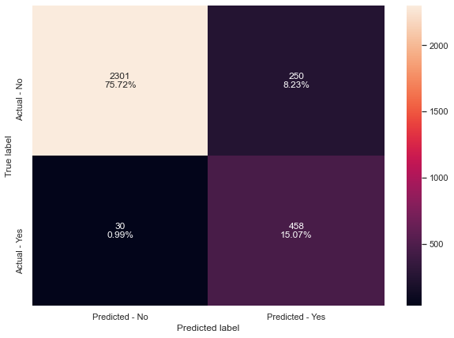

```python
# Calculating different metrics
get_metrics_score(xgb_tuned1)

# Creating confusion matrix
make_confusion_matrix(xgb_tuned1, y_test)
```

## Hyperparameter tuning using random search

- Tuning of some models using ramdonized search - Use of pipelines in hyperparameter tuning

### XGBoost - RandomizedSearchCV

```python
%%time

#Creating pipeline
pipe=make_pipeline(StandardScaler(),XGBClassifier(random_state=1,eval_metric='logloss', n_estimators = 50))

#Parameter grid to pass in GridSearchCV
param_grid={'xgbclassifier__n_estimators':np.arange(50,200,50),
            'xgbclassifier__scale_pos_weight':[0,1,2,5,8],
            'xgbclassifier__learning_rate':[0.01,0.1,0.2],
            'xgbclassifier__gamma':[0,1,3,5],
            'xgbclassifier__subsample':[0.7,0.8,0.9],
           'xgbclassifier__max_depth':np.arange(1,9,2),
            'xgbclassifier__reg_lambda':[0,1,2,5]}





# Type of scoring used to compare parameter combinations
scorer = metrics.make_scorer(metrics.recall_score)

#Calling RandomizedSearchCV
randomized_cv = RandomizedSearchCV(estimator=pipe, param_distributions=param_grid, n_iter=50, scoring=scorer, cv=5, random_state=1)

#Fitting parameters in RandomizedSearchCV
randomized_cv.fit(X_train,y_train)

print("Best parameters are {} with CV score={}:" .format(randomized_cv.best_params_,randomized_cv.best_score_))
```

```
Best parameters are {'xgbclassifier__subsample': 0.9, 'xgbclassifier__scale_pos_weight': 8, 'xgbclassifier__reg_lambda': 1, 'xgbclassifier__n_estimators': 150, 'xgbclassifier__max_depth': 5, 'xgbclassifier__learning_rate': 0.01, 'xgbclassifier__gamma': 1} with CV score=0.9385423912203417:
Wall time: 1min 51s
```

```python
# Creating new pipeline with best parameters
xgb_tuned2 = Pipeline(
    steps=[
        ("scaler", StandardScaler()),
        (
            "XGB",
            XGBClassifier(
                random_state=1,
                n_estimators=150,
                scale_pos_weight=8,
                gamma=1,
                subsample=0.9,
                learning_rate= 0.01,
                eval_metric='logloss', max_depth = 5, reg_lambda = 1
            ),
        ),
    ]
)
# Fit the model on training data
xgb_tuned2.fit(X_train, y_train)
```

```
Pipeline(steps=[('scaler', StandardScaler()),
                ('XGB',
                 XGBClassifier(base_score=0.5, booster='gbtree',
                               colsample_bylevel=1, colsample_bynode=1,
                               colsample_bytree=1, eval_metric='logloss',
                               gamma=1, gpu_id=-1, importance_type='gain',
                               interaction_constraints='', learning_rate=0.01,
                               max_delta_step=0, max_depth=5,
                               min_child_weight=1, missing=nan,
                               monotone_constraints='()', n_estimators=150,
                               n_jobs=4, num_parallel_tree=1, random_state=1,
                               reg_alpha=0, reg_lambda=1, scale_pos_weight=8,
                               subsample=0.9, tree_method='exact',
                               validate_parameters=1, verbosity=None))])
```

```
Accuracy on training set :  0.9211343115124153
Accuracy on test set :  0.9012833168805529
Recall on training set :  0.9727831431079894
Recall on test set :  0.9467213114754098
Precision on training set :  0.6772616136919315
Precision on test set :  0.6277173913043478
```

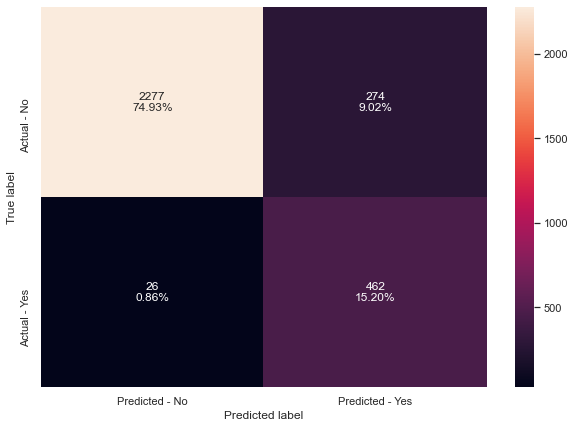

```python
# Calculating different metrics
get_metrics_score(xgb_tuned2)

# Creating confusion matrix
make_confusion_matrix(xgb_tuned2, y_test)
```

## Model Performances

- Comparing the model performance of all the models - Comment on the time taken by the grid and randomized search in optimization

### Comparing all models

```python
# defining list of models
models = [rf_estimator, rf_estimator_tuned, xgb, xgb_tuned1, xgb_tuned2]

# defining empty lists to add train and test results
acc_train = []
acc_test = []
recall_train = []
recall_test = []
precision_train = []
precision_test = []

# looping through all the models to get the metrics score - Accuracy, Recall and Precision
for model in models:

    j = get_metrics_score(model, False)
    acc_train.append(j[0])
    acc_test.append(j[1])
    recall_train.append(j[2])
    recall_test.append(j[3])
    precision_train.append(j[4])
    precision_test.append(j[5])
```

```python
comparison_frame = pd.DataFrame(
    {
        "Model": [
            "Random Forest",
            "RF with GridSearchCV",
            "XGBoost",
            "XGBoost with GridSearchCV",
            "XGBoost with RandomizedSearchCV",

        ],
        "Train_Accuracy": acc_train,
        "Test_Accuracy": acc_test,
        "Train_Recall": recall_train,
        "Test_Recall": recall_test,
        "Train_Precision": precision_train,
        "Test_Precision": precision_test,
    }
)

# Sorting models in decreasing order of test recall
comparison_frame.sort_values(by="Test_Recall", ascending=False)
```

|  | Model | Train_Accuracy | Test_Accuracy | Train_Recall | Test_Recall | Train_Precision | Test_Precision |
| --- | --- | --- | --- | --- | --- | --- | --- |
| 4 | XGBoost with RandomizedSearchCV | 0.921134 | 0.901283 | 0.972783 | 0.946721 | 0.677262 | 0.627717 |
| 3 | XGBoost with GridSearchCV | 0.935384 | 0.907864 | 0.986831 | 0.938525 | 0.717294 | 0.646893 |
| 2 | XGBoost | 0.998589 | 0.955577 | 0.997366 | 0.877049 | 0.993876 | 0.850895 |
| 1 | RF with GridSearchCV | 0.979120 | 0.954919 | 0.919227 | 0.862705 | 0.949229 | 0.857434 |
| 0 | Random Forest | 1.000000 | 0.956236 | 1.000000 | 0.848361 | 1.000000 | 0.875264 |

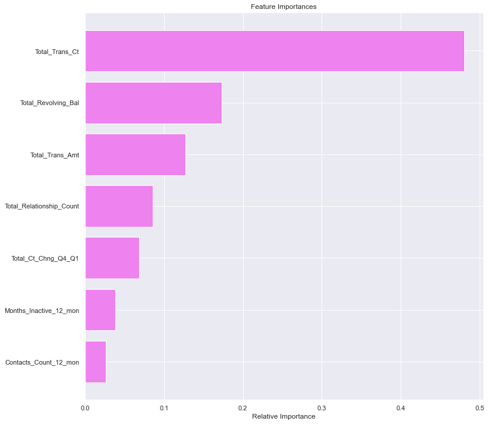

```python
feature_names = X_train.columns
importances = xgb_tuned2[1].feature_importances_
indices = np.argsort(importances)

plt.figure(figsize=(12, 12))
plt.title("Feature Importances")
plt.barh(range(len(indices)), importances[indices], color="violet", align="center")
plt.yticks(range(len(indices)), [feature_names[i] for i in indices])
plt.xlabel("Relative Importance")
plt.show()
```

- Total_Trans_Ct and Total_Revolving_Bal are the most important features to decide the Attrition of a costumer credit card account in the case of the most performant model in the test recall, that is, the XGB model tuned with a Random CVsearch.
- The drawback of this tuned model is that the test precision drops to the 63%.
- The XGBoost model without tuning can be an equilibrated model in the test recall (88%) and the test precision (85%).
- Similarly the RF with GridSearchCV presents a similar performance than the XGBoost model.
- These last two models could be compete in order to be put in production.

## Actionable Insights & Recommendations

- Business recommendations and insights

### Business Recommendations

**Relative to the costumers:**

- The most important features to decide the Attrition of an account are: Total_Trans_Ct, Total_Revolving_Bal and Total_Trans_Amt.
- Also the Total_Relationship_Count and Total_Ct_Chng_Q4_Q1 are features important to take this decision by the side of the costumers.

**Relative to the best models:**

- The XGBoost model without tuning and the RF with GridSearchCV can be equilibrated models in the test recall (88%) and the test precision (85%) to be considererd in production.
- If a better performance in the test recall (94%) is required the tuned XGBoost model with RandomSearchCV is the best option but there will a dropping of the test precision to 63%.